# Text as Data

W8: Topic Models and Their Variants

Yen-Chieh Liao

2026-10-30Fall 2026 (115-1) · National Taiwan University (GIND)  
NTLDEV 7191 · Fri. 16:30–18:20 · GIND 204  
Last compiled: 2026-11-06 16:22:26 (Asia/Taipei)

## Political positions and issue attention

| Research task | Political question |
| --- | --- |
| W7: text scaling | Where does a speaker stand on a defined dimension? |
| W8: issue attention | What does a political actor choose to discuss? |

Campaign promises, newspaper frames, policy diffusion and social media show different uses of topic models.

We begin with each study’s political puzzle.

Reference: W7 scaling; [Grimmer, Roberts & Stewart (2022)](https://ingramacademic.com/products/text-as-data-9780691207551)

## Research questions and model use

**Guiding question:** How do political scientists turn large text collections into evidence about political behavior and communication?

We first read five political studies. Then we unpack how the models work and apply them to political speeches in R.

Reference: [Grimmer, Roberts & Stewart (2022)](https://ingramacademic.com/products/text-as-data-9780691207551); [ESS course](https://essexsummerschool.com/course/ess-2026-course-list/1k/)

## Topic models in political research

| Case | Texts | How the model is used |
| --- | --- | --- |
| **1 · Catalinac (2016)** | Japanese manifestos | Measure campaign promises |
| **2 · Gilardi et al. (2021)** | U.S. news paragraphs | Study policy diffusion and framing |
| **3 · Barberá et al. (2019)** | Tweets | Measure daily issue attention |
| **4 · Jiang et al. (2024)** | Hong Kong news | Develop and test a hypothesis |
| **5 · Roberts et al. (2014)** | Survey answers | Compare priorities with human coding |

Reference: [Catalinac (2016)](https://doi.org/10.1086/683073); [Gilardi, Shipan & Wüest (2021)](https://doi.org/10.1111/ajps.12521); [Barberá et al. (2019)](https://doi.org/10.1017/S0003055419000352); [Jiang, Xia & Zhang (2024)](https://doi.org/10.1007/s11109-023-09900-y); [Roberts et al. (2014)](https://doi.org/10.1111/ajps.12103)

## How we will read each case

| What to find | Question for the reader |
| --- | --- |
| Political question | What puzzle does the study want to explain? |
| Texts and document unit | What counts as one document, and whose language appears? |
| Model contribution | What does the topic model discover or measure? |
| Evidence and limits | What comparison, dynamic model or experiment supports the claim? |

Use the same four questions when you design your own text research.

Teaching guide for the five cases introduced on the previous page.

## Electoral rules and campaign promises

**Case 1 · Campaign priorities**

[figure not shown]

**Amy Catalinac**

Journal of Politics, 2016

- **Puzzle:** the 1994 reform reduced same-party competition, but later studies still described campaigns as pork-oriented.
- **Question:** did candidates shift from benefits for small groups to broader public policies?
- **Evidence:** 7,497 candidate manifestos from eight elections, 1986–2009.

Reference: [Catalinac (2016)](https://doi.org/10.1086/683073)

## Manifestos become campaign-priority measures

**Case 1 · How LDA is used · 1/3**

| Research step | What Catalinac does |
| --- | --- |
| Discover topics | LDA identifies 69 recurring themes in 7,497 manifestos |
| Read and check | Inspect 15 top words and 10 representative manifestos per topic |
| Define concepts | Use who benefits to classify 14 pork and 52 policy topics |
| Measure candidates | Sum each category's topic shares within every manifesto |
| Test the puzzle | Compare those shares across elections and levels of same-party competition |

LDA finds recurring themes; close reading gives them political meaning.

Reference: [Catalinac (2016)](https://doi.org/10.1086/683073)

## Manifestos become campaign-priority measures

**Case 1 · How LDA is used · 2/3**

| Research step | What Catalinac does |
| --- | --- |
| Discover topics | LDA identifies 69 recurring themes in 7,497 manifestos |
| Read and check | Inspect 15 top words and 10 representative manifestos per topic |
| Define concepts | Use who benefits to classify 14 pork and 52 policy topics |
| Measure candidates | Sum each category's topic shares within every manifesto |
| Test the puzzle | Compare those shares across elections and levels of same-party competition |

Catalinac classifies interpreted topics by who benefits, creating pork and policy measures.

Reference: [Catalinac (2016)](https://doi.org/10.1086/683073)

## Manifestos become campaign-priority measures

**Case 1 · How LDA is used · 3/3**

| Research step | What Catalinac does |
| --- | --- |
| Discover topics | LDA identifies 69 recurring themes in 7,497 manifestos |
| Read and check | Inspect 15 top words and 10 representative manifestos per topic |
| Define concepts | Use who benefits to classify 14 pork and 52 policy topics |
| Measure candidates | Sum each category's topic shares within every manifesto |
| Test the puzzle | Compare those shares across elections and levels of same-party competition |

Candidate-level shares are compared across elections and levels of same-party competition.

Reference: [Catalinac (2016)](https://doi.org/10.1086/683073)

## Pork and policy across Japanese elections

**Case 1 · The measure enters the result**

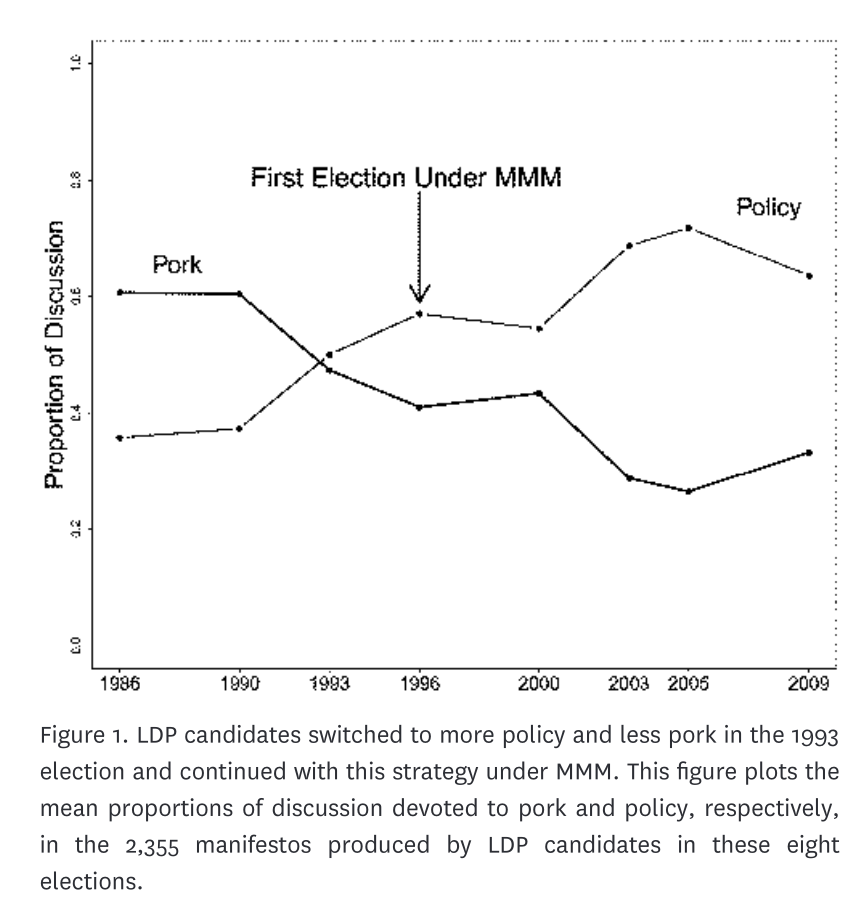

Reference: [Catalinac (2016)](https://doi.org/10.1086/683073)

## Pork and policy across Japanese elections

**Case 1 · The measure enters the result**

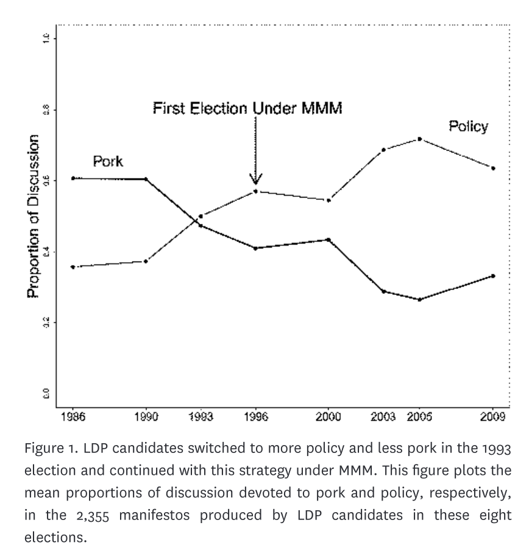

Now follow the lower line: **local-benefit promises** fall while broad policy promises rise.

Reference: [Catalinac (2016)](https://doi.org/10.1086/683073)

## Competition and campaign priorities

**Case 1 · A complementary comparison**

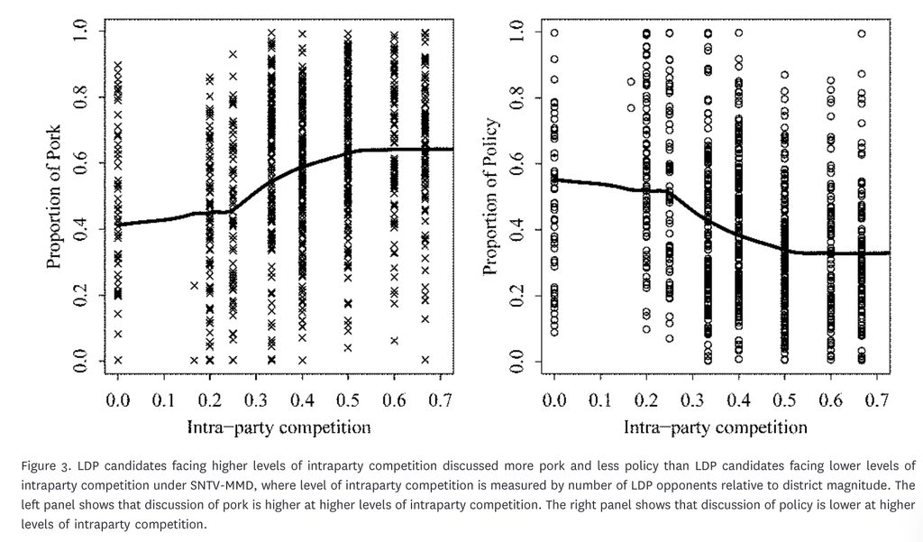

Left panel: more **same-party rivals** are linked to more local-benefit promises.

Reference: [Catalinac (2016)](https://doi.org/10.1086/683073)

## Competition and campaign priorities

**Case 1 · A complementary comparison**

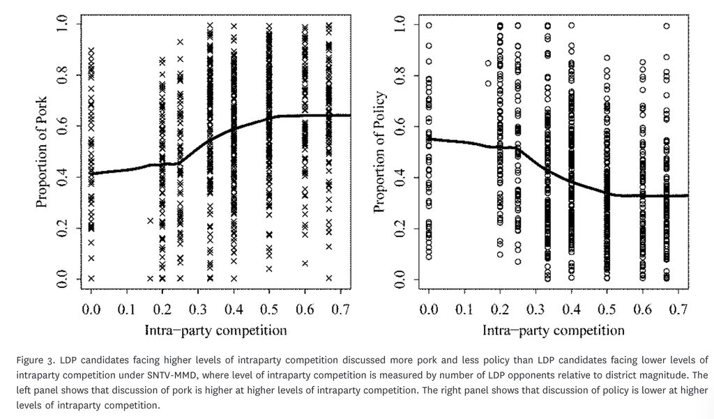

Right panel: more **same-party rivals** are linked to fewer broad policy promises.

Reference: [Catalinac (2016)](https://doi.org/10.1086/683073)

## Opposition candidates emphasize policy

**Case 1 · Opposition comparison**

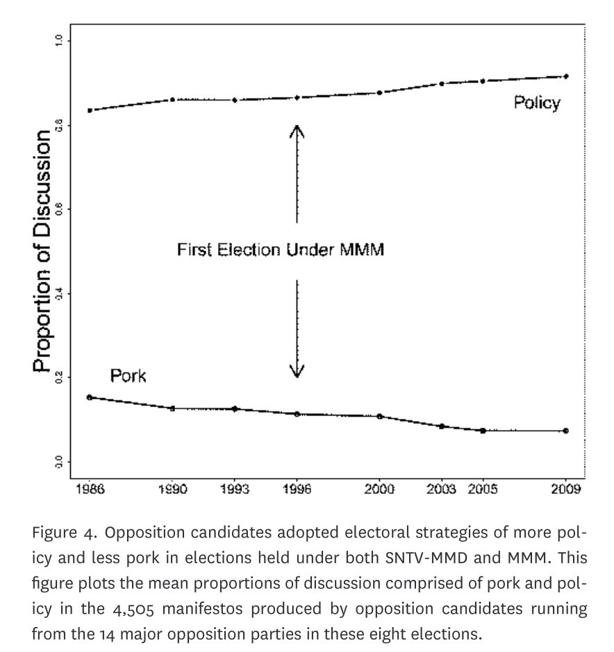

The opposition already makes many **broad policy promises** before 1996, and the line stays high.

Reference: [Catalinac (2016)](https://doi.org/10.1086/683073)

## Opposition candidates emphasize policy

**Case 1 · Opposition comparison**

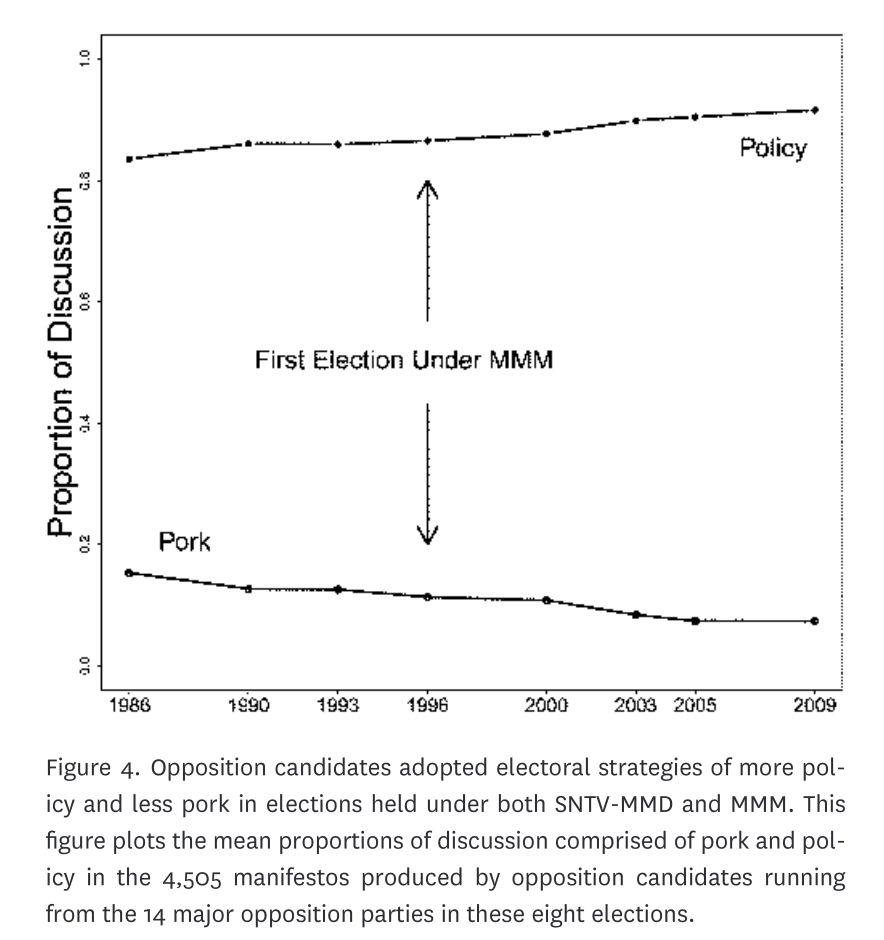

The opposition’s **local-benefit promises** stay low. This observational comparison does not identify a causal effect.

Reference: [Catalinac (2016)](https://doi.org/10.1086/683073)

## Policy diffusion before adoption

**Case 2 · Issue definition**

[figure not shown]

**Fabrizio Gilardi, Charles R. Shipan and Bruno Wüest**

American Journal of Political Science, 2021

- **Puzzle:** diffusion research usually observes policy adoption after the debate has already begun.
- **Question:** do earlier smoking bans elsewhere change how a state’s newspapers define the issue?
- **Evidence:** 52,675 paragraphs from 49 state newspapers, 1996–2013.

Reference: [Gilardi, Shipan & Wüest (2021)](https://doi.org/10.1111/ajps.12521)

## News paragraphs become policy frames

**Case 2 · How STM is used · 1/3**

| Research step | What the researchers do |
| --- | --- |
| Collect reporting | Search 49 state newspapers, 1996–2013 |
| Keep relevant paragraphs | Use crowd labels to train an SVM relevance filter |
| Discover frames | Fit a 12-topic STM to 52,675 paragraphs |
| Measure issue definition | Estimate how common each frame is |
| Study diffusion | Relate frame prevalence to earlier adoptions in other states |

First collect possible reports, then use human labels to keep relevant paragraphs.

Reference: [Gilardi, Shipan & Wüest (2021)](https://doi.org/10.1111/ajps.12521)

## News paragraphs become policy frames

**Case 2 · How STM is used · 2/3**

| Research step | What the researchers do |
| --- | --- |
| Collect reporting | Search 49 state newspapers, 1996–2013 |
| Keep relevant paragraphs | Use crowd labels to train an SVM relevance filter |
| Discover frames | Fit a 12-topic STM to 52,675 paragraphs |
| Measure issue definition | Estimate how common each frame is |
| Study diffusion | Relate frame prevalence to earlier adoptions in other states |

STM finds recurring frames; topic prevalence measures how common each frame is.

Reference: [Gilardi, Shipan & Wüest (2021)](https://doi.org/10.1111/ajps.12521)

## News paragraphs become policy frames

**Case 2 · How STM is used · 3/3**

| Research step | What the researchers do |
| --- | --- |
| Collect reporting | Search 49 state newspapers, 1996–2013 |
| Keep relevant paragraphs | Use crowd labels to train an SVM relevance filter |
| Discover frames | Fit a 12-topic STM to 52,675 paragraphs |
| Measure issue definition | Estimate how common each frame is |
| Study diffusion | Relate frame prevalence to earlier adoptions in other states |

The analysis relates frame prevalence to earlier policy adoptions in connected states.

Reference: [Gilardi, Shipan & Wüest (2021)](https://doi.org/10.1111/ajps.12521)

## Practical policy frames change

**Case 2 · Learning from other states**

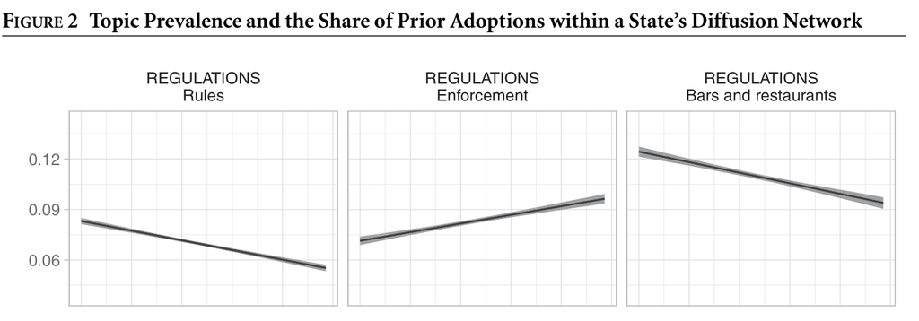

Moving right means more related states have adopted a ban. Restaurant concerns fall, while enforcement becomes more prominent.

Reference: [Gilardi, Shipan & Wüest (2021)](https://doi.org/10.1111/ajps.12521)

## Some frames remain stable

**Case 2 · Stable frame: Health**

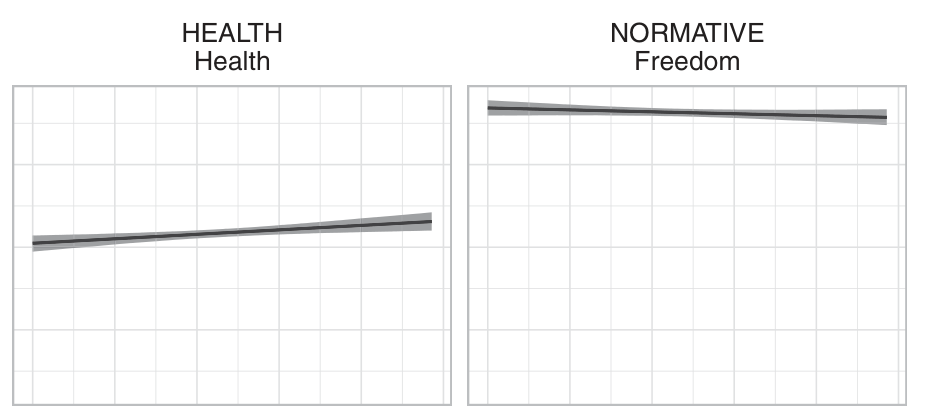

Health changes little as prior adoption rises.

Reference: [Gilardi, Shipan & Wüest (2021)](https://doi.org/10.1111/ajps.12521)

## Some frames remain stable

**Case 2 · Stable frame: Freedom**

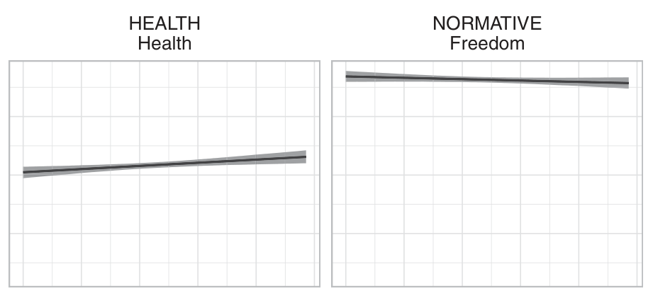

Freedom also stays nearly flat across adoption levels.

Reference: [Gilardi, Shipan & Wüest (2021)](https://doi.org/10.1111/ajps.12521)

## Frames remain separate at lower adoption

**Case 2 · Optional detail · lower adoption**

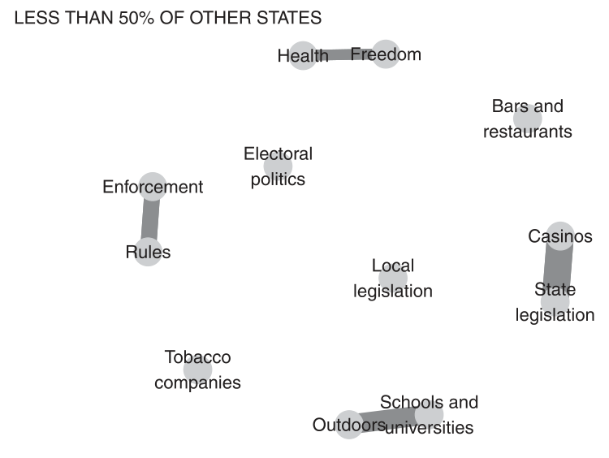

At lower adoption, the Rules topic has few strong correlations with the other frames.

Reference: [Gilardi, Shipan & Wüest (2021)](https://doi.org/10.1111/ajps.12521)

## A broader frame emerges at higher adoption

**Case 2 · Optional detail · higher adoption**

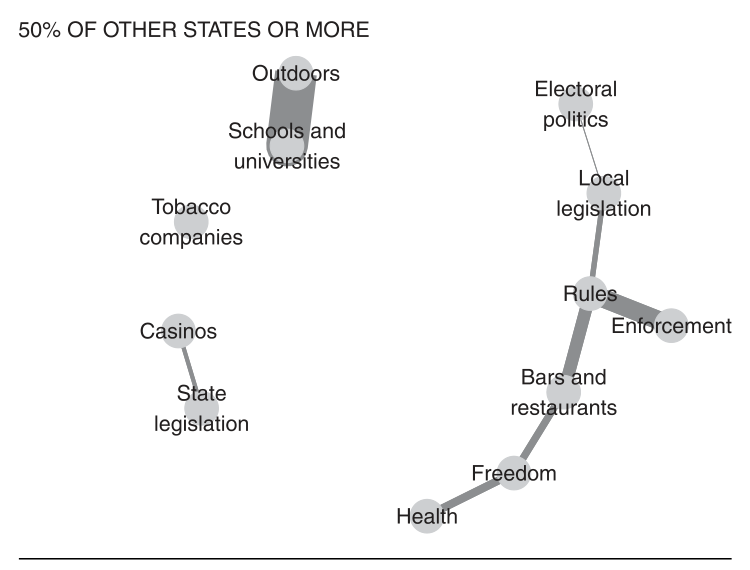

At higher adoption, Rules is correlated with several practical, value and political frames.

Reference: [Gilardi, Shipan & Wüest (2021)](https://doi.org/10.1111/ajps.12521)

## Who leads? Who follows?

**Case 3 · Social media and issue attention**

[figure not shown]

**Pablo Barberá and colleagues**

American Political Science Review, 2019

- **Question:** do politicians lead public attention, or follow it?
- **Texts:** Congress, public and media tweets, 2013–2014.
- **Use:** compare daily attention to shared issues.

Reference: [Barberá et al. (2019)](https://doi.org/10.1017/S0003055419000352)

## Tweets become daily issue-attention measures

**Case 3 · How the topic model is used · 1/3**

| Research step | What the researchers do |
| --- | --- |
| Define documents | Combine congressional tweets by day, party and chamber |
| Discover shared themes | Fit a 100-topic LDA to the grouped congressional texts |
| Interpret issues | Read topic words and merge related political themes |
| Construct measures | Estimate daily issue attention for politicians, public samples and media |
| Analyse timing | Compare whose earlier attention predicts another group's later attention |

Tweets are grouped into comparable daily documents before LDA finds recurring themes.

Reference: [Barberá et al. (2019)](https://doi.org/10.1017/S0003055419000352)

## Tweets become daily issue-attention measures

**Case 3 · How the topic model is used · 2/3**

| Research step | What the researchers do |
| --- | --- |
| Define documents | Combine congressional tweets by day, party and chamber |
| Discover shared themes | Fit a 100-topic LDA to the grouped congressional texts |
| Interpret issues | Read topic words and merge related political themes |
| Construct measures | Estimate daily issue attention for politicians, public samples and media |
| Analyse timing | Compare whose earlier attention predicts another group's later attention |

Researchers turn interpreted topics into comparable daily attention measures.

Reference: [Barberá et al. (2019)](https://doi.org/10.1017/S0003055419000352)

## Tweets become daily issue-attention measures

**Case 3 · How the topic model is used · 3/3**

| Research step | What the researchers do |
| --- | --- |
| Define documents | Combine congressional tweets by day, party and chamber |
| Discover shared themes | Fit a 100-topic LDA to the grouped congressional texts |
| Interpret issues | Read topic words and merge related political themes |
| Construct measures | Estimate daily issue attention for politicians, public samples and media |
| Analyse timing | Compare whose earlier attention predicts another group's later attention |

Daily attention enters a time-series model that compares who moves first.

Reference: [Barberá et al. (2019)](https://doi.org/10.1017/S0003055419000352)

## Who responds to whose attention?

**Case 3 · Direction one**

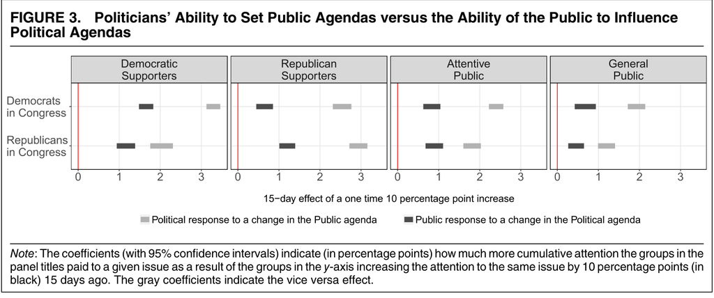

**Gray:** when public attention rises, politicians often pay more attention later.

Reference: [Barberá et al. (2019)](https://doi.org/10.1017/S0003055419000352)

## Who responds to whose attention?

**Case 3 · Reverse direction and caveat**

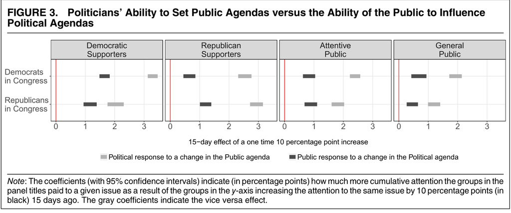

**Black:** when politicians’ attention rises, the public may pay more attention later.

Reference: [Barberá et al. (2019)](https://doi.org/10.1017/S0003055419000352)

## Immigration and shared democratic values

**Case 4 · Topic models for theory building**

[figure not shown]

**Jin Jiang, Shouzhi Xia and Dong Zhang**

Political Behavior, 2024

- **Puzzle:** research emphasizes economic and cultural concerns more than shared political values.
- **Question:** can shared democratic values reduce support for restrictive immigration policy?
- **Evidence:** researchers use the STM results to develop the hypothesis. A preregistered experiment tests it.

Reference: [Jiang, Xia & Zhang (2024)](https://doi.org/10.1007/s11109-023-09900-y)

## From news topics to a hypothesis

**Case 4 · How STM supports theory building · 1/3**

| Research step | Use in this article |
| --- | --- |
| Discover concerns | STM identifies five topics in 4,453 news articles |
| Read and label | Inspect characteristic words and representative news |
| Compare over time | Estimate changes in topic prevalence, 2003–2020 |
| Build a hypothesis | Rising political attention motivates a shared-values argument |
| Test separately | Randomize messages in a preregistered experiment |

STM finds recurring concerns; researchers read the texts and supply the labels.

Reference: [Jiang, Xia & Zhang (2024)](https://doi.org/10.1007/s11109-023-09900-y)

## From news topics to a hypothesis

**Case 4 · How STM supports theory building · 2/3**

| Research step | Use in this article |
| --- | --- |
| Discover concerns | STM identifies five topics in 4,453 news articles |
| Read and label | Inspect characteristic words and representative news |
| Compare over time | Estimate changes in topic prevalence, 2003–2020 |
| Build a hypothesis | Rising political attention motivates a shared-values argument |
| Test separately | Randomize messages in a preregistered experiment |

Changes in topic attention motivate the shared-democratic-values hypothesis.

Reference: [Jiang, Xia & Zhang (2024)](https://doi.org/10.1007/s11109-023-09900-y)

## From news topics to a hypothesis

**Case 4 · How STM supports theory building · 3/3**

| Research step | Use in this article |
| --- | --- |
| Discover concerns | STM identifies five topics in 4,453 news articles |
| Read and label | Inspect characteristic words and representative news |
| Compare over time | Estimate changes in topic prevalence, 2003–2020 |
| Build a hypothesis | Rising political attention motivates a shared-values argument |
| Test separately | Randomize messages in a preregistered experiment |

Researchers use the STM results to develop the hypothesis. Random assignment tests the message effect.

Reference: [Jiang, Xia & Zhang (2024)](https://doi.org/10.1007/s11109-023-09900-y)

## Changing attention to mainland immigration

**Case 4 · Theory-building evidence**

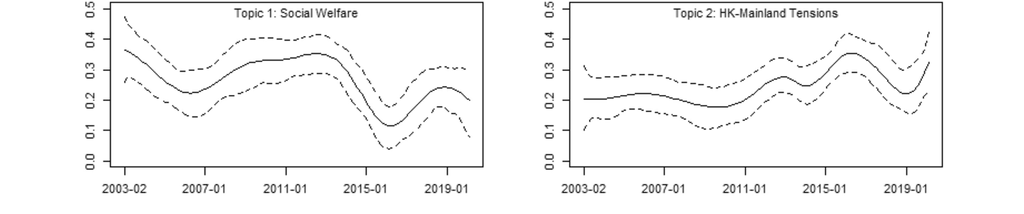

News attention to social welfare falls after the mid-2010s. Dashed lines show 95% uncertainty.

Reference: [Jiang, Xia & Zhang (2024)](https://doi.org/10.1007/s11109-023-09900-y)

## Changing attention to mainland immigration

**Case 4 · Hypothesis development**

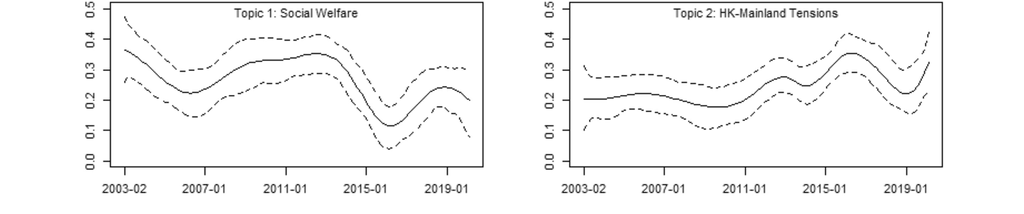

Attention to HK–Mainland tensions rises. This pattern motivates a shared-values hypothesis.

Reference: [Jiang, Xia & Zhang (2024)](https://doi.org/10.1007/s11109-023-09900-y)

## National problems in respondents’ own words

**Case 5 · Public issue priorities**

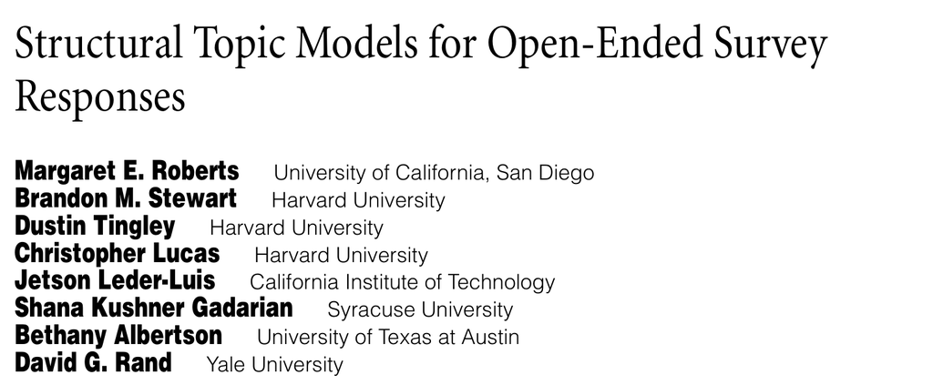

**Margaret E. Roberts and colleagues**

American Journal of Political Science, 2014

- **Question:** who names war as a national problem?
- **Document:** one ANES open-ended answer.
- **Comparison:** party identification and education.

Reference: [Roberts et al. (2014)](https://doi.org/10.1111/ajps.12103)

## Survey answers become issue comparisons

**Case 5 · How the model is used**

| Step | Role in the research design |
| --- | --- |
| Texts | Answers to the most-important-national-problem question |
| Model inputs | 60-topic STM; party, education, age and party × education |
| Output used | Estimated war-related share in each answer |
| Political comparison | War-topic relationship with party and education |
| Check | Compare with ANES human-coded war categories |

**Human category codes provide a benchmark; they do not train this STM.**

Reference: [Roberts et al. (2014)](https://doi.org/10.1111/ajps.12103)

## Survey priorities and human-coded evidence

**Case 5 · Human-coded benchmark**

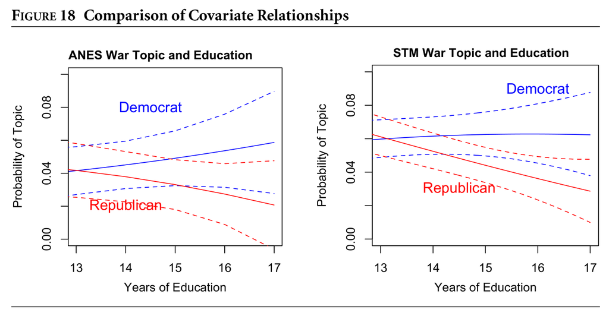

Left: the human-coded party gap is larger at higher education.

Reference: [Roberts et al. (2014)](https://doi.org/10.1111/ajps.12103)

## Survey priorities and human-coded evidence

**Case 5 · STM comparison**

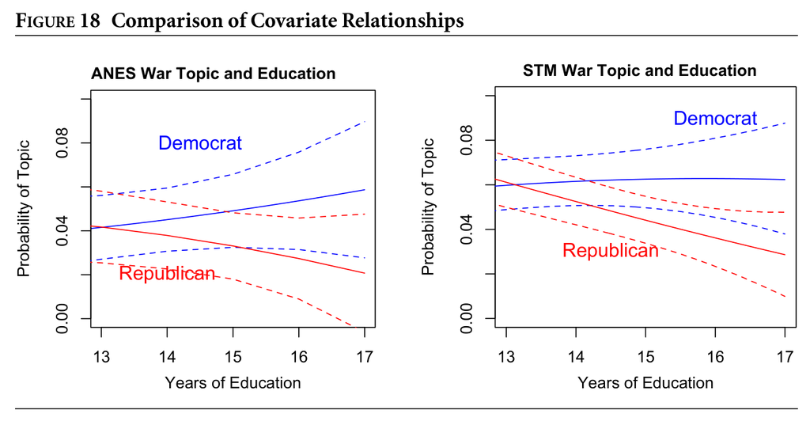

Right: the STM also shows a wider party gap; the Democratic line is roughly flat.

Reference: [Roberts et al. (2014)](https://doi.org/10.1111/ajps.12103)

## From topics to political evidence

| Study | Model contribution | Next research step |
| --- | --- | --- |
| Catalinac | Topic shares | Define pork/policy; compare candidates |
| Gilardi et al. | Frame proportions | Relate frames to prior policy adoption |
| Barberá et al. | Daily attention | Compare who moves first |
| Jiang et al. | Topic trends | Develop a hypothesis; test separately |
| Roberts et al. | Survey topic shares | Compare patterns with human coding |

**The research design determines what the evidence supports.**

Reference: [Catalinac (2016)](https://doi.org/10.1086/683073); [Gilardi, Shipan & Wüest (2021)](https://doi.org/10.1111/ajps.12521); [Barberá et al. (2019)](https://doi.org/10.1017/S0003055419000352); [Jiang, Xia & Zhang (2024)](https://doi.org/10.1007/s11109-023-09900-y); [Roberts et al. (2014)](https://doi.org/10.1111/ajps.12103)

## Applying topic models to political speeches

**In-class demonstration**

**Political question:** Which issues do party leaders emphasize in their speeches?

**Question**what issues receive attention?

→

**Documents**one complete speech each

→

**Word counts**tokenize and clean

→

**Topic models**LDA and STM

→

**Research use**interpret, compare and check K

We will explore themes with LDA, add document information with STM, then compare topic resolutions using perplexity and original texts.

**One workflow:** fit, interpret, compare and validate.

Data source: Essex Summer School 2026, Day 7; British House of Commons party-leader speeches. W8 fixed teaching sample: 719 speeches.

## Step 1: Read the speeches

**LDA application · 1/6**

```r
library(quanteda)

data_dir <- "analysis/ess_lab"
topic_docs <- readRDS(file.path(
  data_dir, "sample_raw.rds"))

topic_corpus <- corpus(
  topic_docs,
  text_field = "text",
  docid_field = "doc_id")
```

**Corpus = a collection of texts**

**719 complete speeches**

**The example used on all six pages**

| Field | Value |
| --- | --- |
| ID | `ess_hoc_00004` |
| Leader | Margaret Thatcher |
| Party | Conservative |
| Date | 1979-06-26 |

**Here, one document means one complete speech.** The corpus keeps each speech together with its ID and background information.

Data source: Essex Summer School 2026, Day 7, British House of Commons party-leader speeches (p. 3). W8 fixed teaching sample: 719 speeches.

## Step 2: Split one speech into words

**LDA application · 2/6**

```r
id <- "ess_hoc_00004"

raw_tokens <- tokens(
  topic_corpus[id],
  what = "word")

raw_tokens[[id]][1:21]
```

**Original sentence**

“With permission, Mr. Speaker I should like to make a statement on the European Council Meeting at Strasbourg.”

**First 21 raw tokens**

```
“With” “permission” “,” “Mr” “.” “Speaker”
“I” “should” “like” “to” “make” “a” “statement”
“on” “the” “European” “Council” “Meeting” “at” “Strasbourg” “.”
```

**Tokenization splits a speech into separate units.** At this stage, punctuation and common words can still appear.

Data source: Essex Summer School 2026, Day 7; British House of Commons party-leader speeches. Example: speech `ess_hoc_00004`.

## Step 3: Remove words that do not help

**LDA application · 3/6**

```r
clean_tokens <- tokens(
  topic_corpus,
  remove_punct = TRUE,
  remove_numbers = TRUE) |>
  tokens_tolower() |>
  tokens_remove(c(
    stopwords("en"),
    "mr", "speaker"))

clean_tokens[[id]][1:8]
```

**First eight cleaned tokens**

```
“permission” “like” “make” “statement”
“european” “council” “meeting” “strasbourg”
```

Remove punctuation  
Use lowercase  
Remove very common words

**Cleaning keeps the words that the model will compare.** Every removal rule needs a reason.

Data source: Essex Summer School 2026, Day 7; British House of Commons party-leader speeches. W8 fixed teaching sample: 719 speeches.

## Step 4: Fit the LDA model

**LDA application · 4/6**

**Full DFM after cleaning: 719 × 2,831**

```r
# Use the DFM constructed in Lab R01c.
set.seed(20260710)
lda_6 <- seededlda::textmodel_lda(
  topic_dfm,
  k = 6,
  alpha = .5, beta = .1,
  max_iter = 500,
  auto_iter = FALSE,
  batch_size = 1,
  verbose = FALSE)
```

**What the fitted model stores**

| Output | Question it answers |
| --- | --- |
| Topic–word probabilities | Which words characterize each topic? |
| Document–topic proportions | Which topics appear in each speech? |

A speech can mix topics; each topic favors different words. LDA estimates both from word patterns across the corpus.

**This fit uses the full DFM built in the Lab.** The short cleaning example on the previous page is for illustration.

Data source: Essex Summer School 2026, Day 7, British House of Commons party-leader speeches (p. 21). [seededlda documentation](https://koheiw.github.io/seededlda/reference/textmodel_lda.html).

## Step 5: Topic words

**LDA application · 5/6**

`terms(lda_6, 5)` shows the five highest-probability words in each topic.

| Topic | Highest-probability words | Provisional reading |
| --- | --- | --- |
| T1 | european, council, community, countries, agreed | European Council negotiations |
| T2 | government, state, made, members, service | Government and public service? |
| T3 | prime, people, government, said, can | General political leadership? |
| T4 | government, people, unemployment, economy, year | Economy and unemployment |
| T5 | people, can, country, want, support | Public appeals and support? |
| T6 | united, must, international, security, nations | International security |

**Topic words suggest a provisional label.** Original speeches show whether the label holds.

Data source: W8 six-topic LDA fitted to the fixed sample of 719 British House of Commons party-leader speeches. Student Lab R02a.

## Step 6: One document’s topics

**LDA application · 6/6**

```r
topic_names <- c(
  "European Council negotiations",
  "Government and public service?",
  "General political leadership?",
  "Economy and unemployment",
  "Public appeals and support?",
  "International security")

id <- "ess_hoc_00004"
i <- match(id, topic_docs$doc_id)

doc_topics <- lda_6$theta[i, ]
round(doc_topics, 3)

dominant_topic <- which.max(doc_topics)
topic_names[dominant_topic]
```

**Document `ess_hoc_00004`**

| T1 | T2 | T3 | T4 | T5 | T6 |
| --- | --- | --- | --- | --- | --- |
| **.874** | .067 | .012 | .002 | .012 | .032 |

**Largest share:** T1  
**Provisional name:** European Council negotiations

> “…a statement on the European Council Meeting at Strasbourg.”

**The document keeps all six proportions.** The dominant topic is a short summary of its largest share.

Data source: W8 six-topic LDA and original speech `ess_hoc_00004`. Student Lab R02b–R03b.

## Using STM to compare party attention

**Question:** do Conservative and Labour leaders emphasize the same issues?

| Keep from the LDA example | Add for the STM example |
| --- | --- |
| The same 719 complete speeches | Party and election period for each speech |
| The same word-count matrix | A model of how topic shares vary with this information |

We will follow the same Thatcher speech, then compare one topic across parties.

**Focus: topic prevalence — how much a topic is discussed.**

Reference: [Roberts et al. (2014)](https://doi.org/10.1111/ajps.12103)

## STM Step 1: Add document information

**STM application · 1/5 · In-class demonstration**

```r
metadata <- data.frame(
  doc_id = topic_docs$doc_id,
  party_family = topic_docs$party_family,
  period = topic_docs$period)
i <- match("ess_hoc_00004", metadata$doc_id)
metadata[i, c("party_family", "period")]
```

**The same speech: `ess_hoc_00004`**

| Field | Stored value |
| --- | --- |
| Party | Conservative |
| Election period | 47th Parliament (1979-1983) |

**719 metadata rows**, in the same order as the 719 speech documents.

`period` is a category, not a numeric time trend.

**One speech, one metadata row.** Party and period now accompany the word counts.

W8 in-class demonstration. Same 719 speeches and STM specification as Lab R05.

## STM Step 2: Specify the model

**STM application · 2/5 · In-class demonstration**

**Fit once · reference specification**

```r
stm_input <- convert(topic_dfm, to = "stm")
stm_6 <- stm::stm(
  documents = stm_input$documents,
  vocab = stm_input$vocab, K = 6,
  prevalence = ~ party_family + period,
  data = metadata, seed = 20260710,
  init.type = "Spectral", max.em.its = 100,
  emtol = 1e-4, verbose = FALSE)
```

**Read the fitted result**

```r
dim(stm_6$theta)
```

**Output:** 719 documents × 6 topics.

`prevalence = ~ party_family + period`

Party and period help model topic shares. Word choice within topics is shared in this example.

**Metadata enters topic estimation.** R05a fits this specification in the Lab.

W8 in-class demonstration. Same 719 speeches and STM specification as Lab R05. [stm reference](https://search.r-project.org/CRAN/refmans/stm/help/stm.html).

## STM Step 3: Read one topic

**STM application · 3/5 · In-class demonstration**

```r
stm::labelTopics(
  stm_6, topics = 4, n = 5)

round(stm_6$theta[i, 4], 3)
```

**STM Topic 4**

| Word summary | Five characteristic words |
| --- | --- |
| Probability | council, community, agreed, united, european |
| FREX | argentine, commonwealth, nations, agreed, meeting |

**Provisional label:** International affairs?

The same Thatcher speech has **97.9%** in this STM topic.

**Read words and original text together.** Topic numbers belong to their own fitted model.

W8 in-class demonstration. Same 719 speeches and STM specification as Lab R05. Selected probability/FREX words from R05a; original speech ess_hoc_00004.

## STM Step 4: Compare party averages

**STM application · 4/5 · In-class demonstration**

```r
party_means <- tapply(
  stm_6$theta[, 4],
  metadata$party_family, mean)

round(100 * party_means, 2)
```

**Mean share of STM Topic 4**

| Party | Mean topic share |
| --- | --- |
| Conservative | 13.66% |
| Labour | 7.63% |

**Raw Labour − Conservative:** -6.03 percentage points.

Each sampled speech has equal weight.

**These are descriptive averages.** The speeches come from different election periods.

W8 in-class demonstration. Same 719 speeches and STM specification as Lab R05. Same unadjusted means as R05b.

## STM Step 5: Account for election period

**STM application · 5/5 · In-class demonstration**

```r
set.seed(20260710)
party_effects <- stm::estimateEffect(
  1:6 ~ party_family + period,
  stm_6, metadata, uncertainty = "Global", nsims = 50)
set.seed(20260710)
z <- plot(party_effects, covariate = "party_family",
  method = "difference", cov.value1 = "Labour",
  cov.value2 = "Conservative", topics = 1:6,
  nsims = 1000, omit.plot = TRUE, labeltype = "numbers")
round(100 * c(z$means[[4]], z$cis[[4]]), 2)
```

**Adjusted comparison · Topic 4**

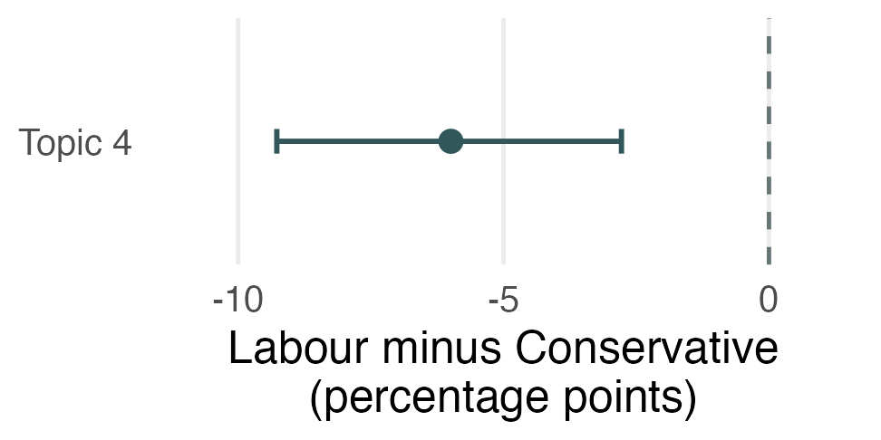

| Quantity | Percentage points |
| --- | --- |
| Labour − Conservative | -5.99 |
| 95% interval | [-9.27, -2.78] |

**The comparison accounts for election period.** It describes a conditional association.

W8 in-class demonstration. Same 719 speeches and STM specification as Lab R05. Exact R05c–R05d conditional difference; plot selects Topic 4 only.

## Assumptions and document boundaries

| Modelling choice | Question for the researcher |
| --- | --- |
| Bag of words | Does word order carry information we need? |
| A common set of topics | Are language and topic meanings comparable across the corpus? |
| Document boundaries | Does one speech contain enough context for a mixture? |
| Vocabulary selection | Which distinctions survive cleaning and trimming? |
| K | Which issues split or merge when the number of topics changes? |
| Alpha and initialization | Are mixtures and results stable across reasonable settings? |

**These choices shape the topics before researchers name or compare them.**

Reference: [Blei, Ng & Jordan (2003)](https://www.jmlr.org/papers/v3/blei03a.html); [ESS course](https://essexsummerschool.com/course/ess-2026-course-list/1k/); [Grimmer, Roberts & Stewart (2022)](https://ingramacademic.com/products/text-as-data-9780691207551)

## Topic validation asks different questions

| Check | Question |
| --- | --- |
| Held-out word fit | Can the model account for unseen words? |
| Words and documents | Does the label describe the content? |
| Coherence and exclusivity | Are prominent words related and distinctive? |
| Sensitivity | Does the interpretation survive reasonable choices? |
| External prediction | Do topic shares predict an outcome outside estimation? |

Reference: [ESS course](https://essexsummerschool.com/course/ess-2026-course-list/1k/); [Grimmer, Roberts & Stewart (2022)](https://ingramacademic.com/products/text-as-data-9780691207551)

## Checking a topic label

**STM Topic 4 · provisional label: “International affairs”**

| Evidence | What to check |
| --- | --- |
| Probability words | council, community, agreed, united, european |
| FREX words | argentine, commonwealth, nations, agreed, meeting |
| Same Thatcher speech | European Council meeting in Strasbourg; T4 = 97.9% |
| Other speeches | Read high-share texts and possible counterexamples |

**Decision:** retain, narrow, broaden or reject the label.

One speech supports a label; validate it on other texts.

Reference: [Ying, Montgomery & Stewart (2022)](https://doi.org/10.1017/pan.2021.33)

## Reading perplexity

**K:** number of topics. **Perplexity:** a model fit score.

| Step | What to do |
| --- | --- |
| 1 · Fit candidate models | Same texts and vocabulary; e.g. LDA K = 3, 6, 9 |
| 2 · Compare scores | Lower perplexity = better fit to the words being scored |
| 3 · Read the topics | Check topic words and original texts: are the labels useful? |
| 4 · Choose a useful K | Use the score and interpretation together |

**Lab R04 uses training words. A lower score alone does not establish the best K.**

Reference: [Blei, Ng & Jordan (2003)](https://www.jmlr.org/papers/v3/blei03a.html); [Wallach et al. (2009)](https://doi.org/10.1145/1553374.1553515); [Roberts, Stewart & Tingley (2019)](https://doi.org/10.18637/jss.v091.i02)

## Held-out prediction and topic meaning

| Evidence | How to read it |
| --- | --- |
| Training perplexity ↓ | Better reconstruction of the estimation words |
| Held-out prediction | Hide evaluation words before fitting, then score them |
| STM workflow | `make.heldout()` → fit → `eval.heldout()`; compare K with `searchK()` |
| Topic meaning | Read texts; check stability and independent evidence |

**STM held-out log probability: higher is better.** Perplexity: **lower is better.**

**Chang et al. (2009): predictive fit and human interpretation can diverge.**

Reference: [Blei, Ng & Jordan (2003)](https://www.jmlr.org/papers/v3/blei03a.html); [Wallach et al. (2009)](https://doi.org/10.1145/1553374.1553515); [Roberts, Stewart & Tingley (2019)](https://doi.org/10.18637/jss.v091.i02); [Chang et al. (2009)](https://proceedings.neurips.cc/paper/2009/hash/f92586a25bb3145facd64ab20fd554ff-Abstract.html)

## Same texts, different K

**Same speeches and words · selected topics**

| Topics | Possible topic labels | Training perplexity |
| --- | --- | --- |
| **K = 3** | Europe-related discussion | 1,195.7 |
| **K = 9** | EU agreements Council meetings | 989.2 |

**Choose useful detail.**  
A lower score alone does not choose K.

Source: W8 Lab R04a (selected word lists) and R04b (actual training scores).

## Checking the number of topics

**In-class demonstration · Choosing a topic resolution**

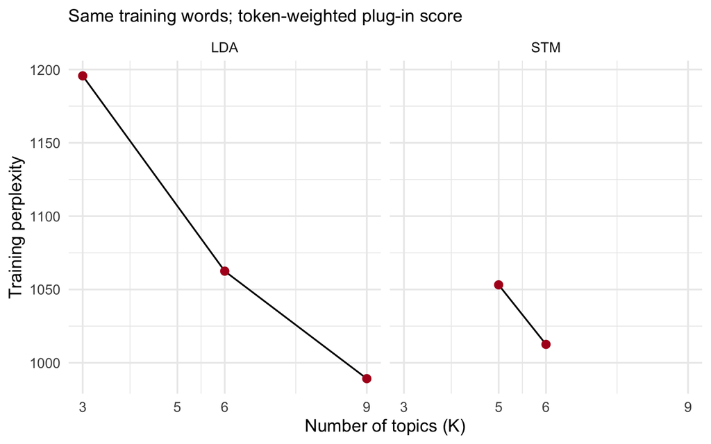

- **LDA, K=3/6/9:** 1195.7 → 1062.5 → 989.2.
- **STM, K=5/6:** 1053.2 → 1012.6.
- Read words and the same texts: does extra K add a useful distinction?

**Lower perplexity means better fit, not proof of the best K.**

K=6 is our teaching resolution. R04b calculation · R04c plot.

Reference: [Blei, Ng & Jordan (2003)](https://www.jmlr.org/papers/v3/blei03a.html); [Chang et al. (2009)](https://proceedings.neurips.cc/paper/2009/hash/f92586a25bb3145facd64ab20fd554ff-Abstract.html)

## Keyword-assisted topic models

**Another modelling choice · keyATM**

**Method paper**

[figure not shown]

Eshima, Imai & Sasaki · AJPS 2024

**R package**

[figure not shown]

`install.packages("keyATM")`

Researchers supply a few keywords for concepts they want to measure. The model estimates topics and document mixtures, including topics without keywords.

Reference: [Eshima, Imai & Sasaki (2024)](https://doi.org/10.1111/ajps.12779)

## Extension · Keyword guidance in two models

| Method | Researcher input | W8 use |
| --- | --- | --- |
| keyATM | Keywords for defined topics, plus topics without keywords | Method and package overview |
| Seeded LDA | Seed dictionary, pseudo-count weight and residual topics | Independent extension |

Both use substantive information to guide topic discovery.

The models and outputs differ; interpret and validate each fit.

[keyATM](https://keyatm.github.io/keyATM/) and [seededlda](https://koheiw.github.io/seededlda/reference/textmodel_seededlda.html). ESS Day 7’s runnable example uses `textmodel_seededlda()`.

## More applications in political research

[figure not shown]

[**Wratil et al. (2023)**](https://doi.org/10.1017/S0003055422001198)

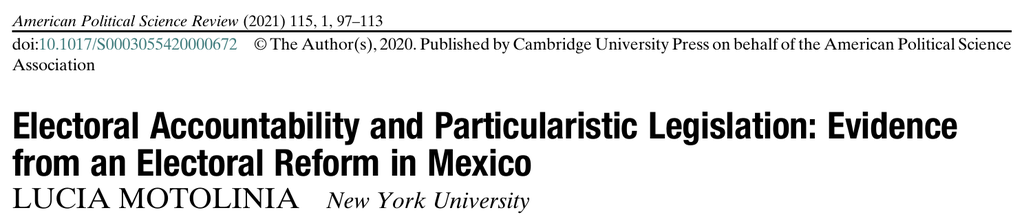

[**Motolinia (2021)**](https://doi.org/10.1017/S0003055420000672)

[figure not shown]

[**Mueller & Rauh (2018)**](https://doi.org/10.1017/S0003055417000570)

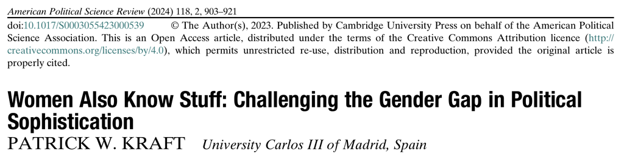

[**Kraft (2024)**](https://doi.org/10.1017/S0003055423000539)

Reference: [Wratil et al. (2023)](https://doi.org/10.1017/S0003055422001198); [Motolinia (2021)](https://doi.org/10.1017/S0003055420000672); [Mueller & Rauh (2018)](https://doi.org/10.1017/S0003055417000570); [Kraft (2024)](https://doi.org/10.1017/S0003055423000539)

## Extension · Correlated topics and change over time

| Model | Research question | What the analyst supplies |
| --- | --- | --- |
| Correlated Topic Model | Which issues tend to appear together in documents? | Text counts and a chosen topic resolution |
| Dynamic Topic Model | How does the language of an issue change across periods? | Comparable texts and ordered time periods |

CTM estimates which issues appear together. DTM tracks how topic vocabulary changes across ordered periods.

Reference: [Blei & Lafferty (2007)](https://doi.org/10.1214/07-AOAS114); [Blei & Lafferty (2006)](https://doi.org/10.1145/1143844.1143859)

## Extension · Short texts with a biterm model

**Short-text applications · R package BTM**

**Original paper · WWW 2013**

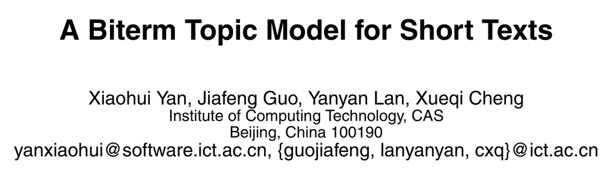

- **Texts:** short survey answers, posts or headlines.
- **BTM:** pools unordered word pairs across short texts.

**R package example**

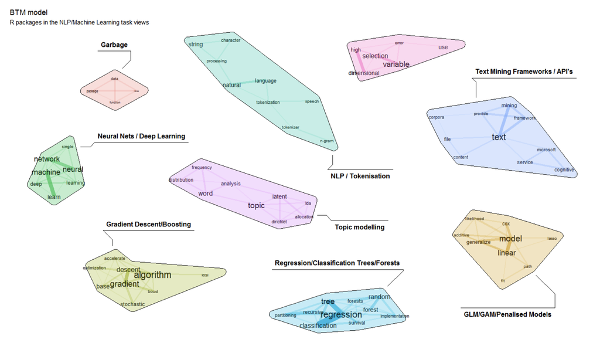

R package descriptions, grouped into topics.

**Your extension:** compare BTM with LDA and check labels against the original texts.

Reference: [Yan et al. (2013)](https://doi.org/10.1145/2488388.2488514); [BTM documentation](https://www.bnosac.be/blog/98-biterm-topic-modelling-for-short-texts); [official R package documentation](https://cran.r-project.org/web/packages/BTM/index.html)

## Break

**Back at 17:36.**

Next: the RStudio project, complete topic mixtures and party comparisons.

Student Lab ZIP includes the RStudio project, step-by-step R script, data and saved models.

W8 classroom materials. Run the R script one checkpoint at a time and keep the original speeches available.

## One speech as one document

| Corpus choice | Shared classroom input |
| --- | --- |
| Source | Commons leader speeches from two parties |
| Eligible source texts | 3,897 nonempty speeches, source terms ≥ 80 |
| Fixed teaching sample | 719 complete speeches, up to 30 per party-period |
| Sample dates | 15 May 1979 to 17 December 2025 |
| Model input | Same document IDs across the fitted R models |

**Discuss:** what changes if every party’s speeches become one document?

Data source: Essex Summer School 2026, Day 7; British House of Commons party-leader speeches. W8 sampling seed 20261028. Nearly balanced party-period sample, not parliamentary word volume.

## R workflow and model objects

| Class stage | Steps | What you should explain |
| --- | --- | --- |
| 1 · Read and prepare | R01a–R01c | Define a document; explain what cleaning changes |
| 2 · Fit and read LDA | R02a–R02b | Read a complete topic mixture |
| 3 · Check a label | R03a–R03b; E02 | Support a label with text and name a challenge |
| 4 · Compare with STM | R05a–R05e; E05 | Interpret direction, percentage points and uncertainty |

**Same texts:** LDA uses counts; STM adds metadata.

**Before class:** R00 packages and project setup. Open `W8_lab.Rproj`, then `W8.R`.

**After class:** R03c–R04c compare party summaries and K diagnostics. The project plan and reading close the deck.

Student Lab · Student ZIP.

## R00a: R packages

**Before class** · Run **R00a** in `W8.R`.

R packages add functions for text analysis, models and plotting.

```r
required <- c("quanteda", "quanteda.textstats", "seededlda", "stm",
  "dplyr", "tidyr", "ggplot2", "jsonlite")
missing <- required[!vapply(required, requireNamespace,
  quietly = TRUE, FUN.VALUE = logical(1))]
if (length(missing)) stop("Install these packages first: ",
  paste(missing, collapse = ", "))
invisible(lapply(required, function(p)
  suppressPackageStartupMessages(library(p, character.only = TRUE))))
options(width = 100, seededlda_threads = 1)
cat("Packages loaded:", paste(required, collapse = ", "), "\n")
```

```
Packages loaded: quanteda, quanteda.textstats, seededlda, stm, dplyr, tidyr, ggplot2, jsonlite
```

**Before class · Check:** If you see Install these packages first, install the listed packages and rerun this step.

R step-by-step Lab R00a. Same 719 speeches. Full step and output. Executed Console output.

## R00b: Project folders

**Before class** · Run **R00b** in `W8.R`.

```r
lab_file <- function(name) file.path("analysis", "ess_lab", name)
if (!file.exists(lab_file("sample_raw.rds"))) {
  stop("Open W8_lab.Rproj, then run R00b again.")
}
party_colors <- c(Conservative = "#003B73", Labour = "#B00020")
cat("W8 speech input found. Ready to build and fit both models.\n")
```

```
W8 speech input found. Ready to build and fit both models.
```

**Before class · Check:** If the file check fails, reopen W8_lab.Rproj and rerun R00b.

R step-by-step Lab R00b. Same 719 speeches. Full step and output. Executed Console output.

## R01a: Read file

**Run together** · Run **R01a** in `W8.R`.

```r
topic_docs <- readRDS(lab_file("sample_raw.rds"))
topic_corpus <- corpus(
  topic_docs, text_field = "text", docid_field = "doc_id")
print(topic_docs[1:3,
  c("doc_id", "leader", "party_family", "date")])
print(c(speeches = ndoc(topic_corpus)))
```

| Document | Leader | Party | Date |
| --- | --- | --- | --- |
| ess_hoc_00002 | Margaret Thatcher | Conservative | 1979-05-15 |
| ess_hoc_00211 | James Callaghan | Labour | 1979-06-21 |
| ess_hoc_00004 | Margaret Thatcher | Conservative | 1979-06-26 |

Corpus: **719 complete speeches**.

**Run together · Check:** Confirm that the corpus contains 719 speeches and identify the document ID, leader, party, and date.

R step-by-step Lab R01a. Same 719 speeches. Full step and output. Reformatted first three records and the executed corpus count.

## R01b: Split and clean words

**Run together** · Run **R01b** in `W8.R`.

```r
id <- "ess_hoc_00004"
raw_tokens <- tokens(topic_corpus[id], what = "word")
parliamentary_stopwords <- c("hon", "member", "right", "friend", "sir",
  "gentleman", "lady", "house", "commons", "speaker", "minister",
  "secretary", "asked", "question", "mr", "mrs", "ms", "â", "ã")
clean_tokens <- tokens(topic_corpus, remove_punct = TRUE,
  remove_symbols = TRUE, remove_numbers = TRUE, remove_url = TRUE,
  remove_separators = TRUE, split_hyphens = FALSE) |>
  tokens_tolower() |> tokens_remove(stopwords("en")) |>
  tokens_remove(parliamentary_stopwords)
print(raw_tokens[[id]][1:21])
print(clean_tokens[[id]][1:8])
```

**Raw tokens from `ess_hoc_00004`**

```
"With" "permission" "," "Mr" "." "Speaker"
"I" "should" "like" "to" "make" "a"
"statement" "on" "the" "European" "Council" "Meeting"
"at" "Strasbourg" "."
```

**After corpus cleaning**

```
"permission" "like" "make" "statement" "european" "council"
"meeting" "strasbourg"
```

**Run together · Check:** Explain the visible changes between the raw and cleaned words.

R step-by-step Lab R01b. Same 719 speeches. Full step and output. All executed raw and cleaned tokens from the same speech, reflowed six per line. Full Console formatting remains in the Lab.

## R01c: Build the DFM

**Run together** · Run **R01c** in `W8.R`.

```r
collocations <- textstat_collocations(
  clean_tokens, min_count = 8, size = 2:3) |> arrange(desc(lambda))
model_tokens <- tokens_compound(clean_tokens,
  phrase(head(collocations$collocation, 30)))
topic_dfm <- dfm(model_tokens) |>
  dfm_trim(min_termfreq = 5, min_docfreq = 2) |>
  dfm_trim(max_docfreq = .75, docfreq_type = "prop")
topic_dfm <- topic_dfm[ntoken(topic_dfm) > 0, ]
topic_docs <- topic_docs[match(docnames(topic_dfm), topic_docs$doc_id), ]
topic_docs$retained_tokens <- as.numeric(ntoken(topic_dfm))
stopifnot(identical(topic_docs$doc_id, docnames(topic_dfm)))
print(c(speeches = ndoc(topic_dfm), features = nfeat(topic_dfm),
  tokens = sum(ntoken(topic_dfm))))
print(topfeatures(topic_dfm, 6))
```

```
speeches features   tokens
     719     2831    70813
     prime government     people        can        now    country
       992        728        590        490        382        354
```

**Run together · Check:** Confirm the three DFM totals. Explain how compounding and frequency trimming change what the models can see.

R step-by-step Lab R01c. Same 719 speeches. Full step and output. Executed DFM dimensions, retained-token total and all six most frequent retained features.

## R02a: Fit six-topic LDA

**Run together** · Run **R02a** in `W8.R`.

```r
set.seed(20260710)
lda_6 <- textmodel_lda(topic_dfm, k = 6, alpha = .5, beta = .1,
  max_iter = 500, auto_iter = FALSE, batch_size = 1, verbose = FALSE)
print(terms(lda_6, 10))
print(dim(lda_6$theta))
```

| LDA topic | First five of ten printed words |
| --- | --- |
| T1 | european, council, community, countries, agreed |
| T2 | government, state, made, members, service |
| T3 | prime, people, government, said, can |
| T4 | government, people, unemployment, economy, year |
| T5 | people, can, country, want, support |
| T6 | united, must, international, security, nations |

`theta` dimensions: **719 speeches × 6 topics**.

**Run together · Check:** Choose two topics and write provisional labels. Later, check those labels against actual speeches.

R step-by-step Lab R02a. Same 719 speeches. Full step and output. Selected first five words from each printed distribution. The Lab retains all ten.

## R02b: Complete topic mixtures

**Run together** · Run **R02b** in `W8.R`.

```r
print(round(head(lda_6$theta, 3), 3))
print(range(rowSums(lda_6$theta)))
dominant_topic <- max.col(lda_6$theta, ties.method = "first")
names(dominant_topic) <- topic_docs$doc_id
print(head(dominant_topic, 5))
print(table(dominant_topic))
```

| Speech | T1 | T2 | T3 | T4 | T5 | T6 |
| --- | --- | --- | --- | --- | --- | --- |
| 00002 | 0.044 | 0.188 | 0.049 | 0.197 | 0.470 | 0.053 |
| 00211 | 0.005 | 0.490 | 0.136 | 0.207 | 0.116 | 0.045 |
| 00004 | 0.874 | 0.067 | 0.012 | 0.002 | 0.012 | 0.032 |

Dominant-topic counts (T1–T6): **91, 80, 193, 143, 145, 67**.

Full θ rows sum to **1**. Ties use the first index.

**Run together · Check:** Which output can answer: Which issues does one speech discuss as a mixture?

R step-by-step Lab R02b. Same 719 speeches. Full step and output. Reformatted first three θ rows and deterministic dominant-topic summary.

## R03a: Two selected speeches

**Run together** · Run **R03a** in `W8.R`.

```r
theta <- lda_6$theta
high_i <- which.max(theta[, 1])
mixed_i <- which.min(apply(theta, 1, max))
print(topic_docs[c(high_i, mixed_i),
  c("doc_id", "leader", "party_family", "date")])
print(round(theta[c(high_i, mixed_i), ], 4))
print(rowSums(theta[c(high_i, mixed_i), , drop = FALSE]))
```

**A:** `ess_hoc_00004`, Thatcher, 26 June 1979.

**B:** `ess_hoc_05895`, Corbyn, 25 March 2020.

| Speech | T1 | T2 | T3 | T4 | T5 | T6 |
| --- | --- | --- | --- | --- | --- | --- |
| 00004 | 0.8738 | 0.0668 | 0.0124 | 0.0025 | 0.0124 | 0.0322 |
| 05895 | 0.0982 | 0.1339 | 0.2054 | 0.2232 | 0.2054 | 0.1339 |

Both complete mixtures sum to **1** before display rounding.

**Run together · Check:** How does retaining only the largest topic change the description compared with keeping all six proportions?

R step-by-step Lab R03a. Same 719 speeches. Full step and output. Reformatted metadata and all six proportions from both selected speeches.

## R03b: Original speech texts

**Run together** · Run **R03b** in `W8.R`.

```r
cat("Document:", topic_docs$doc_id[high_i], "\n")
cat(topic_docs$text[high_i], "\n")
cat("Mixed document:", topic_docs$doc_id[mixed_i], "\n")
cat(topic_docs$text[mixed_i], "\n")
```

**A: `ess_hoc_00004`**

> With permission, Mr. Speaker I should like to make a statement on the European Council Meeting at Strasbourg. With my…

**B: `ess_hoc_05895`**

> My hon. Friend understands the issue and represents his constituency extremely well. I know that a lot of his constituents…

**Run together · Check:** Find support and a possible challenge to the label. Complete E02; finish E03 after class.

R step-by-step Lab R03b. Same 719 speeches. Full step and output. Opening excerpts from the exact two printed source texts. Complete output in Lab.

## R05a: Fit STM

**Run together** · Run **R05a** in `W8.R`.

```r
metadata <- data.frame(
  doc_id = topic_docs$doc_id,
  party_family = topic_docs$party_family,
  period = topic_docs$period)
design <- model.matrix(~ party_family + period, metadata)
stopifnot(qr(design)$rank == ncol(design))
stm_input <- convert(topic_dfm, to = "stm")
stm_6 <- stm(stm_input$documents, vocab = stm_input$vocab, K = 6,
  prevalence = ~ party_family + period, data = metadata,
  seed = 20260710, init.type = "Spectral", max.em.its = 100,
  emtol = 1e-4, verbose = FALSE)
print(labelTopics(stm_6, topics = 4, n = 5))
```

**STM topic 4.** K=6, prevalence `~ party_family + period`.

| Word summary | Five printed words |
| --- | --- |
| Highest Prob | council, community, agreed, united, european |
| FREX | argentine, commonwealth, nations, agreed, meeting |
| Lift | dependencies, falklands, islanders, moore, shareholders |
| Score | names, argentine, council, islands, commonwealth |

**Run together · Check:** Use the probability words and FREX words to assess the interpretation of the same STM topic.

R step-by-step Lab R05a. Same 719 speeches. Full step and output. All four labelTopics summaries printed by this step.